# CMSC426_Assignment2_sp26

### Track real data - Track 1 point in two frames

```
iteration: 0 , shift_uv_mean: 2.9842176647519683
iteration: 1 , shift_uv_mean: 0.5829880334581579
iteration: 2 , shift_uv_mean: 0.011755563898483711
```

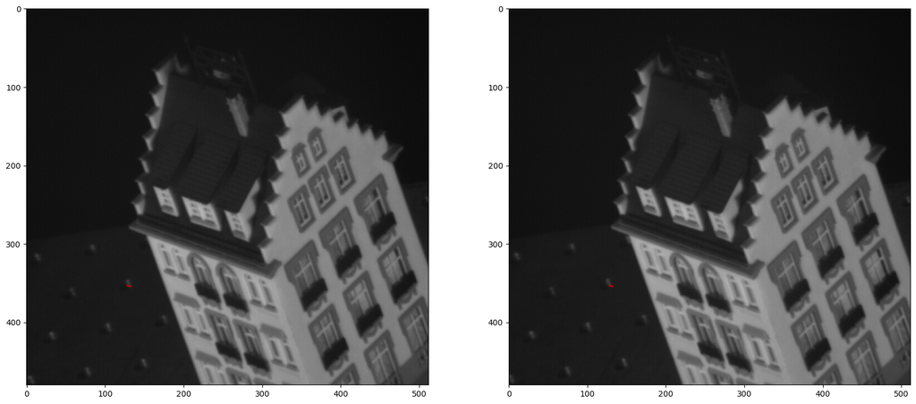

```python
# Parameters setting
# You can start with a smaller number for fast debugging
window_size = 15
iteration = 10

'''
PLEASE DO NOT TOUCH CODES BELOW
'''
in_img = np.zeros(im.shape).astype(np.float32)
in_img[0] = im[0]
in_img[1] = im[1]
in_img = in_img[:2]

start_id = 15
end_id = 16
tracked_x, tracked_y = trackPoints(pt_x=key_pts[start_id:end_id,0], pt_y=key_pts[start_id:end_id,1], im=in_img, ws=window_size, iteration=iteration)

# Plot your results
fig, axs = plt.subplots(1, 2, figsize=(20, 10))
axs[0].imshow(im[0] / 255)
axs[1].imshow(im[1] / 255)

for i in range(tracked_x.shape[1] - 1):
  axs[0].plot([tracked_x[:, i], tracked_x[:, i + 1]], [tracked_y[:, i], tracked_y[:, i + 1]], color=(0.8,0,0), linewidth=2)
  axs[1].plot([tracked_x[:, i], tracked_x[:, i + 1]], [tracked_y[:, i], tracked_y[:, i + 1]], color=(0.8,0,0), linewidth=2)
plt.show()
```

Original point: (132, 354)

Reference image

[figure not shown]

### Track real data - Track 5 points in two frames

```
iteration: 0 , shift_uv_mean: 2.52752908880423
iteration: 1 , shift_uv_mean: 0.4712826247702064
iteration: 2 , shift_uv_mean: 0.009101740641176349
```

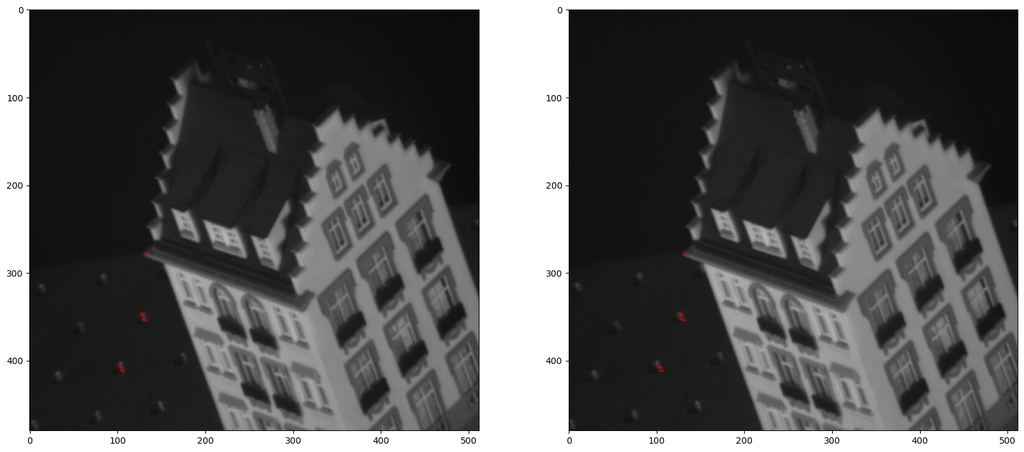

```python
# Parameters setting
# You can start with a smaller number for fast debugging
window_size = 15
iteration = 10

'''
PLEASE DO NOT TOUCH CODES BELOW
'''
in_img = np.zeros(im.shape).astype(np.float32)
in_img[0] = im[0]
in_img[1] = im[1]
in_img = in_img[:2]

start_id = 12
end_id = 17
tracked_x, tracked_y = trackPoints(pt_x=key_pts[start_id:end_id,0], pt_y=key_pts[start_id:end_id,1], im=in_img, ws=window_size, iteration=iteration)

# Plot your results
fig, axs = plt.subplots(1, 2, figsize=(20, 10))
axs[0].imshow(im[0] / 255)
axs[1].imshow(im[1] / 255)

for i in range(tracked_x.shape[1] - 1):
  axs[0].plot([tracked_x[:, i], tracked_x[:, i + 1]], [tracked_y[:, i], tracked_y[:, i + 1]], color=(0.8,0,0), linewidth=2)
  axs[1].plot([tracked_x[:, i], tracked_x[:, i + 1]], [tracked_y[:, i], tracked_y[:, i + 1]], color=(0.8,0,0), linewidth=2)
plt.show()
```

original point: (106, 408), (107, 412), (130, 348), (132, 354), (133, 280)

motion(u, v): (-3, -1), (-3, -1), (-3, -1), (-3, -1), (-3, 0)

reference image:

[figure not shown]

### Track real data - Track all the points in two frames

```
iteration: 0 , shift_uv_mean: 0.7334187785032527
iteration: 1 , shift_uv_mean: 0.027564091478959066
```

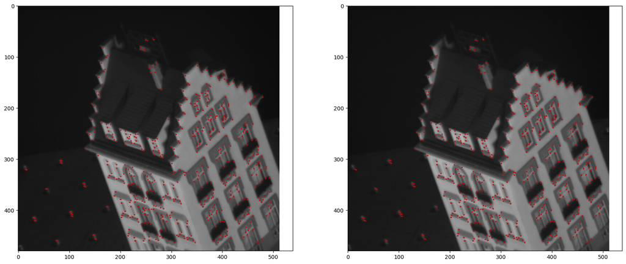

```python
# Parameters setting
# You can start with a smaller number for fast debugging
window_size = 15
iteration = 10

'''
PLEASE DO NOT TOUCH CODES BELOW
'''
in_img = np.zeros(im.shape).astype(np.float32)
in_img[0] = im[0]
in_img[1] = im[1]
in_img = in_img[:2]
tracked_x, tracked_y = trackPoints(pt_x=key_pts[:, 0], pt_y=key_pts[:, 1], im=in_img, ws=window_size, iteration=iteration)

# Plot your results
fig, axs = plt.subplots(1, 2, figsize=(20, 10))
axs[0].imshow(im[0] / 255)
axs[1].imshow(im[1] / 255)

for i in range(tracked_x.shape[1] - 1):
  axs[0].plot([tracked_x[:, i], tracked_x[:, i + 1]], [tracked_y[:, i], tracked_y[:, i + 1]], color=(0.8,0,0), linewidth=2)
  axs[1].plot([tracked_x[:, i], tracked_x[:, i + 1]], [tracked_y[:, i], tracked_y[:, i + 1]], color=(0.8,0,0), linewidth=2)
plt.show()
```

Reference image

[figure not shown]

## Write-up (10 pts)

- (10 pts) For all the keypoints, display (1) the keypoints at the first frame (as green) and (2) the tracked keypoints at the second frame (as red) on the first frame of the sequence.

```
iteration: 0 , shift_uv_mean: 0.7334187785032527
iteration: 1 , shift_uv_mean: 0.027564091478959066
```

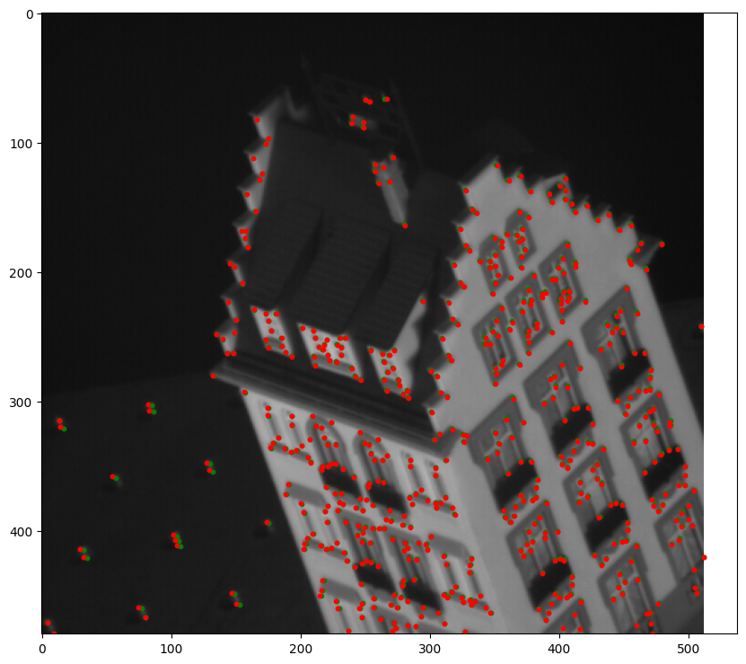

```python
# Parameters setting
# You can start with a smaller number for fast debugging
window_size = 15
iteration = 10

in_img = np.zeros(im.shape).astype(np.float32)
in_img[0] = im[0]
in_img[1] = im[1]
in_img = in_img[:2]
tracked_x, tracked_y = trackPoints(pt_x=key_pts[:, 0], pt_y=key_pts[:, 1], im=in_img, ws=window_size, iteration=iteration)

# Plot the results
fig, ax = plt.subplots(figsize=(10, 10))

# Display the first frame
ax.imshow(im[0] / 255)

ax.scatter(tracked_x[:, 0], tracked_y[:, 0], color='green', s=10)
ax.scatter(tracked_x[:, 1], tracked_y[:, 1], color='red', s=10)

plt.show()
```

[output not shown]

## [Bonus] Track real data - Track all points in all frames (10 points)

```
iteration: 0 , shift_uv_mean: 0.7334187785032527
iteration: 1 , shift_uv_mean: 0.027564091478959066
iteration: 0 , shift_uv_mean: 1.0554099189887705
iteration: 1 , shift_uv_mean: 0.06570146669917394
iteration: 0 , shift_uv_mean: 1.0196099332759399
iteration: 1 , shift_uv_mean: 0.06011625190525963
iteration: 0 , shift_uv_mean: 1.0921646240735063
iteration: 1 , shift_uv_mean: 0.06941261598868903
iteration: 0 , shift_uv_mean: 0.9912531734249213
iteration: 1 , shift_uv_mean: 0.05992718358623231
iteration: 0 , shift_uv_mean: 0.9913761785477213
iteration: 1 , shift_uv_mean: 0.06103785658216647
iteration: 0 , shift_uv_mean: 0.9633991628458954
iteration: 1 , shift_uv_mean: 0.05631815330329303
iteration: 0 , shift_uv_mean: 0.9822926705816919
iteration: 1 , shift_uv_mean: 0.05528930748501044
iteration: 0 , shift_uv_mean: 0.9759466185440595
iteration: 1 , shift_uv_mean: 0.05748772521743205
iteration: 0 , shift_uv_mean: 0.9419684030410378
iteration: 1 , shift_uv_mean: 0.05411020940949794
iteration: 0 , shift_uv_mean: 0.9443157365065342
iteration: 1 , shift_uv_mean: 0.05354884266392692
iteration: 0 , shift_uv_mean: 0.9152576982130431
iteration: 1 , shift_uv_mean: 0.053889347458437854
iteration: 0 , shift_uv_mean: 0.9648729470609911
iteration: 1 , shift_uv_mean: 0.05657426752106022
iteration: 0 , shift_uv_mean: 0.9046206226224562
iteration: 1 , shift_uv_mean: 0.051224743353291254
iteration: 0 , shift_uv_mean: 0.9135404694003102
iteration: 1 , shift_uv_mean: 0.05404089028165937
iteration: 0 , shift_uv_mean: 0.9244460926770754
iteration: 1 , shift_uv_mean: 0.05313022335806473
iteration: 0 , shift_uv_mean: 0.928148162143616
iteration: 1 , shift_uv_mean: 0.05317589947685622
iteration: 0 , shift_uv_mean: 0.9000905644908045
iteration: 1 , shift_uv_mean: 0.04729653405044313
iteration: 0 , shift_uv_mean: 0.9026561562717479
iteration: 1 , shift_uv_mean: 0.04804606518054432
iteration: 0 , shift_uv_mean: 0.876947100930215
iteration: 1 , shift_uv_mean: 0.043078980721727424
```

[output cut: 45 more lines]

```
iteration: 1 , shift_uv_mean: 0.021770798690983632
iteration: 0 , shift_uv_mean: 0.7948310604957498
iteration: 1 , shift_uv_mean: 0.028003636202236025
iteration: 0 , shift_uv_mean: 0.7779814647329949
iteration: 1 , shift_uv_mean: 0.023154150814842074
iteration: 0 , shift_uv_mean: 0.7753188966431166
iteration: 1 , shift_uv_mean: 0.021271540959791158
iteration: 0 , shift_uv_mean: 0.7678943872770316
iteration: 1 , shift_uv_mean: 0.01752857389741771
iteration: 0 , shift_uv_mean: 0.7781428202185345
iteration: 1 , shift_uv_mean: 0.02030641040119309
iteration: 0 , shift_uv_mean: 0.7580875439880758
iteration: 1 , shift_uv_mean: 0.018992106484478962
iteration: 0 , shift_uv_mean: 0.7760050417678992
iteration: 1 , shift_uv_mean: 0.021612460672254998
```

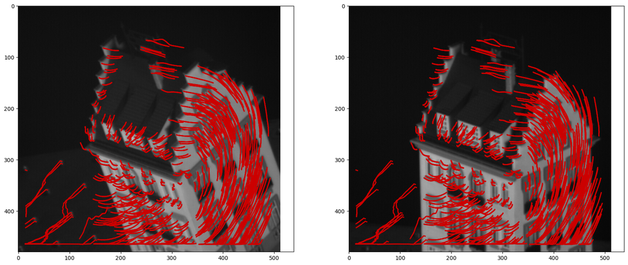

```python
# Parameters setting
# You can start with a smaller number for fast debugging
window_size = 15
iteration = 10

'''
PLEASE DO NOT TOUCH CODES BELOW
'''
tracked_x, tracked_y = trackPoints(pt_x=key_pts[:,0], pt_y=key_pts[:,1], im=im, ws=window_size, iteration=iteration)

# Plot your results
fig, axs = plt.subplots(1, 2, figsize=(20, 10))
axs[0].imshow(im[0] / 255)
axs[1].imshow(im[-1] / 255)

for i in range(tracked_x.shape[1] - 1):
  axs[0].plot([tracked_x[:, i], tracked_x[:, i + 1]], [tracked_y[:, i], tracked_y[:, i + 1]], color=(0.8,0,0), linewidth=2)
  axs[1].plot([tracked_x[:, i], tracked_x[:, i + 1]], [tracked_y[:, i], tracked_y[:, i + 1]], color=(0.8,0,0), linewidth=2)
plt.show()
```

Reference image

[figure not shown]

## [Bonus] Write-up (20 pts)

- (10 pts) For 20 random keypoints, draw the 2D path over the sequence of frames. That is, plot the progression of image coordinates for each of the 20 keypoints. Plot each of the paths on the same figure, overlaid on the first frame of the sequence.

```
iteration: 0 , shift_uv_mean: 0.7574062145130755
iteration: 1 , shift_uv_mean: 0.044778631838318664
iteration: 0 , shift_uv_mean: 0.9474671315462572
iteration: 1 , shift_uv_mean: 0.09048040354596946
iteration: 0 , shift_uv_mean: 0.9391388931420596
iteration: 1 , shift_uv_mean: 0.08313823220562637
iteration: 0 , shift_uv_mean: 0.9758576790825969
iteration: 1 , shift_uv_mean: 0.09763794642308021
iteration: 0 , shift_uv_mean: 0.9062345218026443
iteration: 1 , shift_uv_mean: 0.08472818422548568
iteration: 0 , shift_uv_mean: 0.8993889727550651
iteration: 1 , shift_uv_mean: 0.086041663307353
iteration: 0 , shift_uv_mean: 0.8722602807908368
iteration: 1 , shift_uv_mean: 0.08728555958796064
iteration: 0 , shift_uv_mean: 0.9069317998137645
iteration: 1 , shift_uv_mean: 0.08648551818747373
iteration: 0 , shift_uv_mean: 0.8937495868545063
iteration: 1 , shift_uv_mean: 0.09775736050690217
iteration: 0 , shift_uv_mean: 0.873647607071951
iteration: 1 , shift_uv_mean: 0.10036051231571476
iteration: 0 , shift_uv_mean: 0.8637460503048358
iteration: 1 , shift_uv_mean: 0.10090906936257274
iteration: 0 , shift_uv_mean: 0.8507387340078661
iteration: 1 , shift_uv_mean: 0.1016057790129425
iteration: 0 , shift_uv_mean: 0.883068861371181
iteration: 1 , shift_uv_mean: 0.10952468297763863
iteration: 0 , shift_uv_mean: 0.8801153702282128
iteration: 1 , shift_uv_mean: 0.10682876164389182
iteration: 0 , shift_uv_mean: 0.8808117340528083
iteration: 1 , shift_uv_mean: 0.11091269839237894
iteration: 0 , shift_uv_mean: 0.9025676651736759
iteration: 1 , shift_uv_mean: 0.10872199794178176
iteration: 0 , shift_uv_mean: 0.8518382646766886
iteration: 1 , shift_uv_mean: 0.10645670995318708
iteration: 0 , shift_uv_mean: 0.8443987246799054
iteration: 1 , shift_uv_mean: 0.0840758157687694
iteration: 0 , shift_uv_mean: 0.8369169982809135
iteration: 1 , shift_uv_mean: 0.08967318013523211
iteration: 0 , shift_uv_mean: 0.8134601720115624
iteration: 1 , shift_uv_mean: 0.09268761350339684
```

[output cut: 45 more lines]

```
iteration: 1 , shift_uv_mean: 0.024835154190275963
iteration: 0 , shift_uv_mean: 0.9053757836566373
iteration: 1 , shift_uv_mean: 0.05335560792350064
iteration: 0 , shift_uv_mean: 0.7221624014931909
iteration: 1 , shift_uv_mean: 0.03737683002700034
iteration: 0 , shift_uv_mean: 0.7375591303470209
iteration: 1 , shift_uv_mean: 0.04440223579791706
iteration: 0 , shift_uv_mean: 0.69911011401705
iteration: 1 , shift_uv_mean: 0.016873023350560235
iteration: 0 , shift_uv_mean: 0.7068588332326193
iteration: 1 , shift_uv_mean: 0.017364678472163143
iteration: 0 , shift_uv_mean: 0.6928551320240284
iteration: 1 , shift_uv_mean: 0.014856162402903892
iteration: 0 , shift_uv_mean: 0.7153481448077097
iteration: 1 , shift_uv_mean: 0.02054795753737619
```

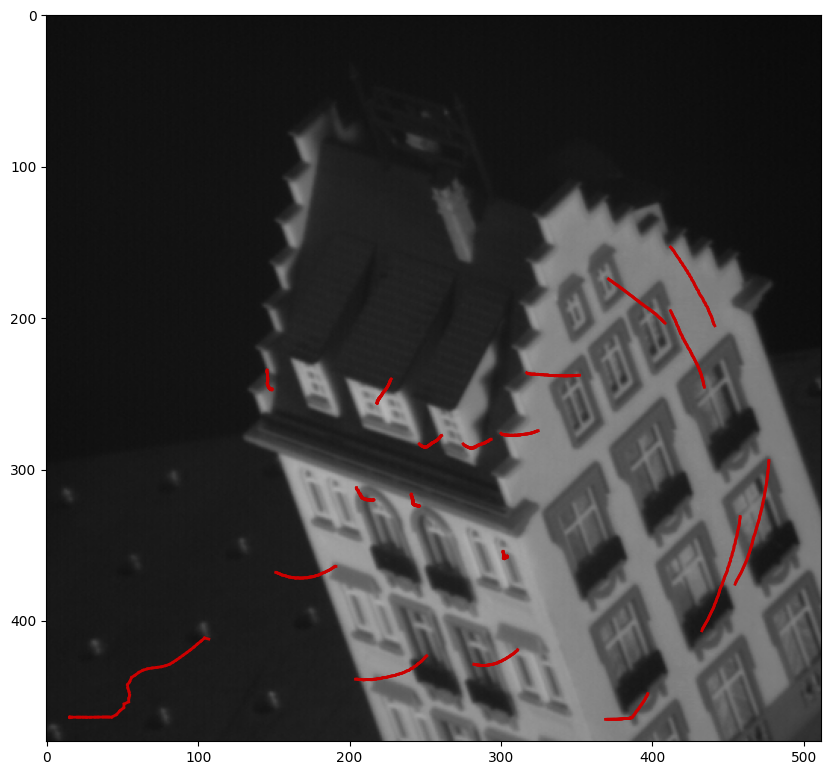

```python
# Parameters setting
# You can start with a smaller number for fast debugging
window_size = 15
iteration = 10

# Get 20 random keypoints
random_indices = np.random.choice(key_pts.shape[0], size=20, replace=False)

tracked_x, tracked_y = trackPoints(pt_x=key_pts[random_indices, 0], pt_y=key_pts[random_indices, 1], im=im, ws=window_size, iteration=iteration)

# Plot the results
fig, ax = plt.subplots(figsize=(10, 10))

# Display the first frame
ax.imshow(im[0] / 255)

# Plot the lines
for i in range(tracked_x.shape[1] - 1):
  ax.plot([tracked_x[:, i], tracked_x[:, i + 1]], [tracked_y[:, i], tracked_y[:, i + 1]], color=(0.8,0,0), linewidth=2)

plt.show()
```

## Export Notebook

```python
from google.colab import drive
drive.mount('/content/drive')
```

```python
!cp /content/drive/MyDrive/CMSC426/CMSC426_Assignment2_sp26.ipynb ./
!jupyter nbconvert --to HTML "CMSC426_Assignment2_sp26.ipynb"
```